# 4. Diabetes Absolute Number with Tax

### Importing necessary libraries

```python
import pandas as pd
import numpy as np
import seaborn as sns
import matplotlib.pyplot as plt
import statsmodels.api as sm

# code to ignore warnings
import warnings
warnings.filterwarnings("ignore")

root_csv = '../csv files/'
root_pickle = '../pickle files/'
```

### Reading files

```python
df_diab_total_pivot = pd.read_pickle(root_pickle +'Diabetes_Total_Pivot.pkl')
df_diab_gender_pivot = pd.read_pickle(root_pickle +'Diabetes_Gender_Pivot.pkl')
df_diab_age_pivot = pd.read_pickle(root_pickle +'Diabetes_Age_Pivot.pkl')
```

### Reviewing data

```python
df_diab_total_pivot.head(5)
```

|  | State | County | CountyFIPS | Year | Total Absolute | Total Percentage | Grocery Tax | Restaurant Tax | tax_delta | Population |
| --- | --- | --- | --- | --- | --- | --- | --- | --- | --- | --- |
| 0 | Alabama | Autauga County | 1001 | 2004 | 2470.0 | 7.5 | 0.04 | 0.04 | 0.0 | 32933.333333 |
| 6 | Alabama | Autauga County | 1001 | 2005 | 3010.0 | 8.9 | 0.04 | 0.04 | 0.0 | 33820.226169 |
| 12 | Alabama | Autauga County | 1001 | 2006 | 3482.0 | 10.0 | 0.04 | 0.04 | 0.0 | 34820.000000 |
| 18 | Alabama | Autauga County | 1001 | 2007 | 3332.0 | 9.4 | 0.04 | 0.04 | 0.0 | 35446.809949 |
| 24 | Alabama | Autauga County | 1001 | 2008 | 3563.0 | 9.9 | 0.04 | 0.04 | 0.0 | 35989.900377 |

```python
df_diab_gender_pivot.head(5)
```

|  | State | County | CountyFIPS | Year | Gender Absolute | Gender Percentage | Gender | Grocery Tax | Restaurant Tax | tax_delta | Population |
| --- | --- | --- | --- | --- | --- | --- | --- | --- | --- | --- | --- |
| 0 | Alabama | Autauga County | 1001 | 2004 | 1281.0 | 7.4 | Female | 0.04 | 0.04 | 0.0 | 17310.810588 |
| 3 | Alabama | Autauga County | 1001 | 2004 | 1189.0 | 7.6 | Male | 0.04 | 0.04 | 0.0 | 15644.737038 |
| 6 | Alabama | Autauga County | 1001 | 2005 | 1523.0 | 8.6 | Female | 0.04 | 0.04 | 0.0 | 17709.301540 |
| 9 | Alabama | Autauga County | 1001 | 2005 | 1487.0 | 9.3 | Male | 0.04 | 0.04 | 0.0 | 15989.246984 |
| 12 | Alabama | Autauga County | 1001 | 2006 | 1758.0 | 9.7 | Female | 0.04 | 0.04 | 0.0 | 18123.711697 |

```python
df_diab_age_pivot.head(5)
```

|  | State | County | CountyFIPS | Year | Age Diabetics Absolute | Age Diabetics Percentage | Age | Grocery Tax | Restaurant Tax | tax_delta | Population |
| --- | --- | --- | --- | --- | --- | --- | --- | --- | --- | --- | --- |
| 0 | Alabama | Autauga County | 1001 | 2004 | 472.0 | 2.900000 | 20-44 | 0.04 | 0.04 | 0.0 | 16275.861534 |
| 1 | Alabama | Autauga County | 1001 | 2004 | 1179.0 | 10.300000 | 45-64 | 0.04 | 0.04 | 0.0 | 11446.601730 |
| 2 | Alabama | Autauga County | 1001 | 2004 | 819.0 | 16.299999 | 65-beyond | 0.04 | 0.04 | 0.0 | 5024.540112 |
| 6 | Alabama | Autauga County | 1001 | 2005 | 582.0 | 3.500000 | 20-44 | 0.04 | 0.04 | 0.0 | 16628.571429 |
| 7 | Alabama | Autauga County | 1001 | 2005 | 1458.0 | 12.300000 | 45-64 | 0.04 | 0.04 | 0.0 | 11853.658353 |

### Regression Analysis at County level data

#### 1. Baseline without controls

##### a. With Total Absolute as Response Variable:

##### Note:

Even though Total Absolute does not make sense as concluded from EDA, we are carrying regression on it.

```python
import numpy as np
import pandas as pd
import statsmodels.api as sm
from sklearn.model_selection import train_test_split
from sklearn.linear_model import LinearRegression
from sklearn.metrics import mean_squared_error, r2_score

# Assuming 'Grocery Tax' and 'Restaurant Tax' are the features
X = df_diab_total_pivot[['Grocery Tax', 'Restaurant Tax']]
y = df_diab_total_pivot['Total Absolute']

# Add a constant term to the features matrix (required for statsmodels)
X = sm.add_constant(X)

# Create and fit the linear regression model using statsmodels
stats_model = sm.OLS(y, X).fit()

# Print the summary
print(stats_model.summary())
```

```
                            OLS Regression Results
==============================================================================
Dep. Variable:         Total Absolute   R-squared:                       0.016
Model:                            OLS   Adj. R-squared:                  0.016
Method:                 Least Squares   F-statistic:                     424.3
Date:                Sat, 25 Nov 2023   Prob (F-statistic):          1.52e-183
Time:                        15:09:00   Log-Likelihood:            -6.0437e+05
No. Observations:               53318   AIC:                         1.209e+06
Df Residuals:                   53315   BIC:                         1.209e+06
Df Model:                           2
Covariance Type:            nonrobust
==================================================================================
                     coef    std err          t      P>|t|      [0.025      0.975]
----------------------------------------------------------------------------------
const           2252.8589    285.866      7.881      0.000    1692.559    2813.159
Grocery Tax    -9.943e+04   4219.610    -23.564      0.000   -1.08e+05   -9.12e+04
Restaurant Tax  1.064e+05   5247.320     20.271      0.000    9.61e+04    1.17e+05
==============================================================================
Omnibus:                    99175.473   Durbin-Watson:                   0.110
Prob(Omnibus):                  0.000   Jarque-Bera (JB):        255602086.837
Skew:                          13.939   Prob(JB):                         0.00
Kurtosis:                     341.048   Cond. No.                         60.9
==============================================================================

Notes:
[1] Standard Errors assume that the covariance matrix of the errors is correctly specified.
```

##### Conclusion:

The baseline model with response as total number of diabetics and predictor variables grocery tax and restaurant tax:

- One percent increase in grocery tax, keeping all other constant, decreases the absolute number by 9.943 x 10^4
- One percent increase in restaurant tax, keeping all other constant, increases the absolute number by 1.064 x 10^5
- p-value is close to 0 in both cases. Hence the coefficients of regression are statistically significant
- Adjusted R-square is 0.016 indicating that the model can explain only 1.6% of variation in total number of diabetics patient
- Again, this model was fitted only on absolute numbers and we will switch to a more better approach of percentages.

#### 2. With single controls

##### a. Gender Control - On Absolute Number

```python
import numpy as np
import pandas as pd
import statsmodels.api as sm
from sklearn.model_selection import train_test_split
from sklearn.linear_model import LinearRegression
from sklearn.metrics import mean_squared_error, r2_score

# One Hot Encoding Gender in predictor variable
X = pd.get_dummies(df_diab_gender_pivot[['Grocery Tax', 'Restaurant Tax', 'Gender']], columns=['Gender'], drop_first=True)
y = df_diab_gender_pivot['Gender Absolute']

# Add a constant term to the features matrix (required for statsmodels)
X = sm.add_constant(X)

# Create and fit the linear regression model using statsmodels
stats_model = sm.OLS(y, X).fit()

# Print the summary
print(stats_model.summary())
```

```
                            OLS Regression Results
==============================================================================
Dep. Variable:        Gender Absolute   R-squared:                       0.016
Model:                            OLS   Adj. R-squared:                  0.016
Method:                 Least Squares   F-statistic:                     564.6
Date:                Sat, 25 Nov 2023   Prob (F-statistic):               0.00
Time:                        15:09:01   Log-Likelihood:            -1.1349e+06
No. Observations:              106631   AIC:                         2.270e+06
Df Residuals:                  106627   BIC:                         2.270e+06
Df Model:                           3
Covariance Type:            nonrobust
==================================================================================
                     coef    std err          t      P>|t|      [0.025      0.975]
----------------------------------------------------------------------------------
const           1127.4711    105.838     10.653      0.000     920.031    1334.911
Grocery Tax    -4.972e+04   1493.471    -33.291      0.000   -5.26e+04   -4.68e+04
Restaurant Tax  5.319e+04   1857.222     28.637      0.000    4.95e+04    5.68e+04
Gender_Male       -1.8496     62.109     -0.030      0.976    -123.582     119.883
==============================================================================
Omnibus:                   198277.356   Durbin-Watson:                   0.065
Prob(Omnibus):                  0.000   Jarque-Bera (JB):        510508501.689
Skew:                          13.943   Prob(JB):                         0.00
Kurtosis:                     340.824   Cond. No.                         69.7
==============================================================================

Notes:
[1] Standard Errors assume that the covariance matrix of the errors is correctly specified.
```

##### Conclusion:

The model with response as total number of diabetics and predictor variables grocery tax and restaurant tax and control on gender:

- One percent increase in grocery tax, keeping all other constant, decreases the absolute number by 4.972 x 10^4
- One percent increase in restaurant tax, keeping all other constant, increases the absolute number by 5.319 x 10^4
- If the gender is male, keeping all other constant, the absolute number decreases by 1.8496.
- p-value of gender male is >0.05. Hence the coefficients of regression of gender is not statistically significant
- Adjusted R-square is 0.016 indicating that the model can explain only 1.6% of variation in total number of diabetics patient
- Again, this model was fitted on absolute numbers and we will switch to a more better approach of percentages.

##### b. Age Control - On Absolute Number

```python
import numpy as np
import pandas as pd
import statsmodels.api as sm
from sklearn.model_selection import train_test_split
from sklearn.linear_model import LinearRegression
from sklearn.metrics import mean_squared_error, r2_score

# One Hot Encoding Gender in predictor variable
X = pd.get_dummies(df_diab_age_pivot[['Grocery Tax', 'Restaurant Tax', 'Age']], columns=['Age'], drop_first=True)
y = df_diab_age_pivot['Age Diabetics Absolute']

# Add a constant term to the features matrix (required for statsmodels)
X = sm.add_constant(X)

# Create and fit the linear regression model using statsmodels
stats_model = sm.OLS(y, X).fit()

# Print the summary
print(stats_model.summary())
```

```
                              OLS Regression Results
==================================================================================
Dep. Variable:     Age Diabetics Absolute   R-squared:                       0.027
Model:                                OLS   Adj. R-squared:                  0.027
Method:                     Least Squares   F-statistic:                     1086.
Date:                    Sat, 25 Nov 2023   Prob (F-statistic):               0.00
Time:                            15:09:01   Log-Likelihood:            -1.6365e+06
No. Observations:                  158645   AIC:                         3.273e+06
Df Residuals:                      158640   BIC:                         3.273e+06
Df Model:                               4
Covariance Type:                nonrobust
==================================================================================
                     coef    std err          t      P>|t|      [0.025      0.975]
----------------------------------------------------------------------------------
const           -441.3035     65.832     -6.703      0.000    -570.333    -312.274
Grocery Tax    -3.341e+04    881.617    -37.891      0.000   -3.51e+04   -3.17e+04
Restaurant Tax  3.575e+04   1103.594     32.390      0.000    3.36e+04    3.79e+04
Age_45-64       1999.2182     45.036     44.391      0.000    1910.948    2087.488
Age_65-beyond   1561.9560     45.038     34.680      0.000    1473.682    1650.230
==============================================================================
Omnibus:                   316955.677   Durbin-Watson:                   0.439
Prob(Omnibus):                  0.000   Jarque-Bera (JB):       1533214613.703
Skew:                          16.176   Prob(JB):                         0.00
Kurtosis:                     483.520   Cond. No.                         68.4
==============================================================================

Notes:
[1] Standard Errors assume that the covariance matrix of the errors is correctly specified.
```

##### Conclusion:

The model with response as total number of diabetics and predictor variables grocery tax and restaurant tax and control on age:

- One percent increase in grocery tax, keeping all other constant, decreases the absolute number by 3.341 x 10^4
- One percent increase in restaurant tax, keeping all other constant, increases the absolute number by 3.575 x 10^4
- If the age is between 45-64, keeping all other constant, the absolute number increases by 1999.21.
- If the age is between 65-beyond, keeping all other constant, the absolute number increases by 1561.96.
- All p values are statistically significant
- Adjusted R-square is 0.027 indicating that the model can explain only 2.7% of variation in total number of diabetics patient
- Again, this model was fitted on absolute numbers and we will switch to a more better approach of percentages.

##### c. Total Population - On Absolute Number

```python
import numpy as np
import pandas as pd
import statsmodels.api as sm
from sklearn.model_selection import train_test_split
from sklearn.linear_model import LinearRegression
from sklearn.metrics import mean_squared_error, r2_score

# Assuming 'Grocery Tax' and 'Restaurant Tax' are the features
X = df_diab_total_pivot[['Grocery Tax', 'Restaurant Tax','Population']]
y = df_diab_total_pivot['Total Absolute']

# Add a constant term to the features matrix (required for statsmodels)
X = sm.add_constant(X)

# Create and fit the linear regression model using statsmodels
stats_model = sm.OLS(y, X).fit()

# Print the summary
print(stats_model.summary())
```

```
                            OLS Regression Results
==============================================================================
Dep. Variable:         Total Absolute   R-squared:                       0.968
Model:                            OLS   Adj. R-squared:                  0.968
Method:                 Least Squares   F-statistic:                 5.344e+05
Date:                Sat, 25 Nov 2023   Prob (F-statistic):               0.00
Time:                        15:09:01   Log-Likelihood:            -5.1319e+05
No. Observations:               53318   AIC:                         1.026e+06
Df Residuals:                   53314   BIC:                         1.026e+06
Df Model:                           3
Covariance Type:            nonrobust
==================================================================================
                     coef    std err          t      P>|t|      [0.025      0.975]
----------------------------------------------------------------------------------
const             80.7462     51.722      1.561      0.118     -20.630     182.122
Grocery Tax     1034.1186    767.215      1.348      0.178    -469.630    2537.867
Restaurant Tax  4161.3196    952.358      4.369      0.000    2294.690    6027.950
Population         0.0855   6.81e-05   1255.840      0.000       0.085       0.086
==============================================================================
Omnibus:                    68483.100   Durbin-Watson:                   0.379
Prob(Omnibus):                  0.000   Jarque-Bera (JB):        423649468.137
Skew:                          -5.904   Prob(JB):                         0.00
Kurtosis:                     439.529   Cond. No.                     1.51e+07
==============================================================================

Notes:
[1] Standard Errors assume that the covariance matrix of the errors is correctly specified.
[2] The condition number is large, 1.51e+07. This might indicate that there are
strong multicollinearity or other numerical problems.
```

#### Conclusion:

```python
# Checking for multicollinearity
from statsmodels.stats.outliers_influence import variance_inflation_factor

vif_data = pd.DataFrame()
vif_data["Variable"] = X.columns
vif_data["VIF"] = [variance_inflation_factor(X.values, i) for i in range(X.shape[1])]

# Check the VIF values
print(vif_data)
```

```
         Variable        VIF
0           const  10.627411
1     Grocery Tax   1.031380
2  Restaurant Tax   1.027672
3      Population   1.016138
```

##### Inference:

The VIF for predictor variables is small and hence multicollinearity does not exist The VIF with constant variable is high. This can be fixed by scaling if needed.

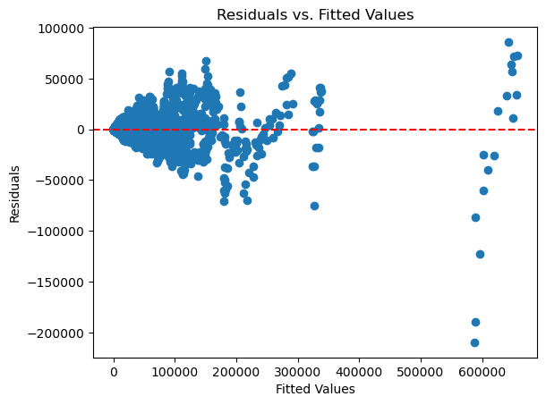

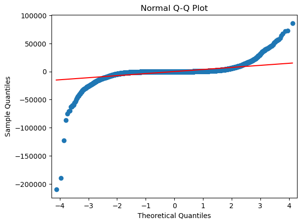

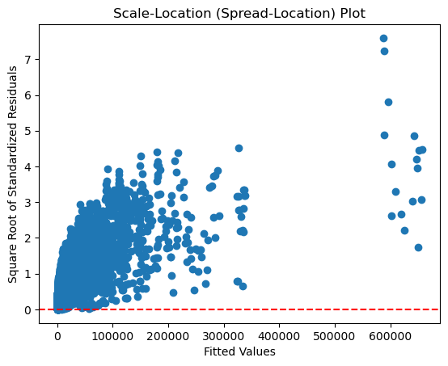

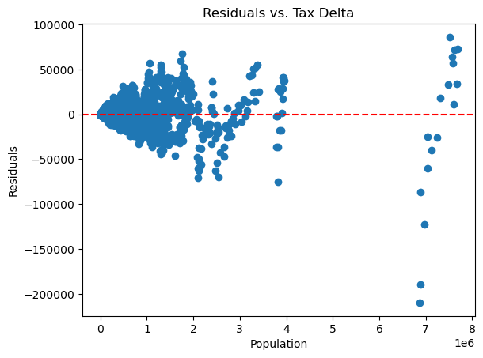

```python
# Validating for linearity assumptions

import statsmodels.api as sm
import matplotlib.pyplot as plt
import scipy.stats as stats
import numpy as np

# Assuming you have already fitted the linear regression model named 'model'

# Get fitted values and residuals
fitted_values = stats_model.fittedvalues
residuals = stats_model.resid

# 1. Residuals vs. Fitted Values Plot
plt.scatter(fitted_values, residuals)
plt.xlabel('Fitted Values')
plt.ylabel('Residuals')
plt.title('Residuals vs. Fitted Values')
plt.axhline(y=0, color='r', linestyle='--')  # Add a horizontal line at y=0
plt.show()

# 2. Normal Q-Q Plot
sm.qqplot(residuals, line='s')
plt.title('Normal Q-Q Plot')
plt.show()

# 3. Scale-Location (Spread-Location) Plot
sqrt_standardized_residuals = np.sqrt(np.abs(stats_model.get_influence().resid_studentized_internal))
plt.scatter(fitted_values, sqrt_standardized_residuals)
plt.xlabel('Fitted Values')
plt.ylabel('Square Root of Standardized Residuals')
plt.title('Scale-Location (Spread-Location) Plot')
plt.axhline(y=0, color='r', linestyle='--')  # Add a horizontal line at y=0
plt.show()

# 4. Residuals vs. Predictor Plot for ''
plt.scatter(df_diab_total_pivot['Population'], residuals)
plt.xlabel('Population')
plt.ylabel('Residuals')
plt.title('Residuals vs. Tax Delta')
plt.axhline(y=0, color='r', linestyle='--')  # Add a horizontal line at y=0
plt.show()
```

##### Inference:

Linearity assumptions are being violated. Lets apply Box-Cox transformations to fix that.

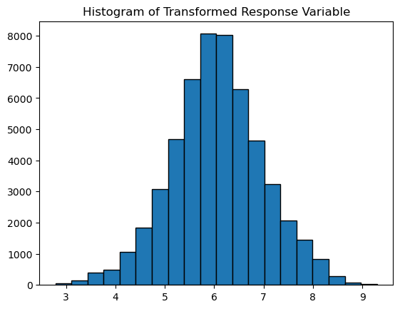

```
Lambda Value: -0.05917551974946644
                            OLS Regression Results
==============================================================================
Dep. Variable:                      y   R-squared:                       0.269
Model:                            OLS   Adj. R-squared:                  0.269
Method:                 Least Squares   F-statistic:                     6539.
Date:                Sat, 25 Nov 2023   Prob (F-statistic):               0.00
Time:                        15:09:04   Log-Likelihood:                -63398.
No. Observations:               53318   AIC:                         1.268e+05
Df Residuals:                   53314   BIC:                         1.268e+05
Df Model:                           3
Covariance Type:            nonrobust
==================================================================================
                     coef    std err          t      P>|t|      [0.025      0.975]
----------------------------------------------------------------------------------
const              5.6681      0.011    505.225      0.000       5.646       5.690
Grocery Tax       -3.9122      0.166    -23.509      0.000      -4.238      -3.586
Restaurant Tax     5.8319      0.207     28.231      0.000       5.427       6.237
Population      1.927e-06   1.48e-08    130.486      0.000     1.9e-06    1.96e-06
==============================================================================
Omnibus:                    20807.276   Durbin-Watson:                   0.096
Prob(Omnibus):                  0.000   Jarque-Bera (JB):           333062.509
Skew:                          -1.451   Prob(JB):                         0.00
Kurtosis:                      14.895   Cond. No.                     1.51e+07
==============================================================================

Notes:
[1] Standard Errors assume that the covariance matrix of the errors is correctly specified.
[2] The condition number is large, 1.51e+07. This might indicate that there are
strong multicollinearity or other numerical problems.
```

```python
# Applying the Box-Cox transformation

# Apply Box-Cox Transformation to Response Variable
y_transformed, lambda_value = stats.boxcox(y + 1)  # Adding 1 to handle zero values

# Visualize the Transformed Response Variable
plt.hist(y_transformed, bins=20, edgecolor='black')
plt.title('Histogram of Transformed Response Variable')
plt.show()

# Check Lambda Value
print(f'Lambda Value: {lambda_value}')

# Fit a new model using the transformed response variable
stats_model_transformed = sm.OLS(y_transformed, X).fit()

# Print the summary of the transformed model
print(stats_model_transformed.summary())
```

##### Conclusion:

```python
import statsmodels.api as sm
from sklearn.preprocessing import StandardScaler
import pandas as pd

df_diab_scaled = df_diab_total_pivot.reset_index(drop=True)
df_diab_scaled

# Extract the independent variables (features) from your DataFrame
X = df_diab_scaled[['Grocery Tax', 'Restaurant Tax', 'Population']]

# Extract the dependent variable from your DataFrame
y = df_diab_scaled['Total Absolute']

# Initialize the StandardScaler
scaler = StandardScaler()

# Fit and transform the independent variables
X_scaled = scaler.fit_transform(X)

# Create a new DataFrame with the scaled features
X_scaled_df = pd.DataFrame(X_scaled, columns=X.columns)

# Add a constant term to the independent variables
X_scaled_df = sm.add_constant(X_scaled_df)

# Fit the linear regression model
model = sm.OLS(y, X_scaled_df).fit()

# Display the summary
print(model.summary())
```

```
                            OLS Regression Results
==============================================================================
Dep. Variable:         Total Absolute   R-squared:                       0.968
Model:                            OLS   Adj. R-squared:                  0.968
Method:                 Least Squares   F-statistic:                 5.344e+05
Date:                Sat, 25 Nov 2023   Prob (F-statistic):               0.00
Time:                        15:09:04   Log-Likelihood:            -5.1319e+05
No. Observations:               53318   AIC:                         1.026e+06
Df Residuals:                   53314   BIC:                         1.026e+06
Df Model:                           3
Covariance Type:            nonrobust
==================================================================================
                     coef    std err          t      P>|t|      [0.025      0.975]
----------------------------------------------------------------------------------
const           6579.9008     15.866    414.721      0.000    6548.804    6610.998
Grocery Tax       21.7183     16.113      1.348      0.178      -9.863      53.300
Restaurant Tax    70.2783     16.084      4.369      0.000      38.754     101.803
Population      2.009e+04     15.993   1255.840      0.000    2.01e+04    2.01e+04
==============================================================================
Omnibus:                    68483.100   Durbin-Watson:                   0.379
Prob(Omnibus):                  0.000   Jarque-Bera (JB):        423649468.143
Skew:                          -5.904   Prob(JB):                         0.00
Kurtosis:                     439.529   Cond. No.                         1.20
==============================================================================

Notes:
[1] Standard Errors assume that the covariance matrix of the errors is correctly specified.
```

##### Since the above model violates linearity assumptions, applying Box-Cox transformation to scaled parameters

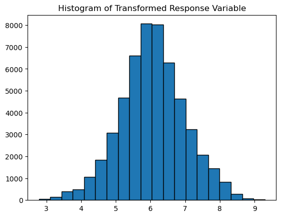

```
Lambda Value: -0.05917551974946644
                            OLS Regression Results
==============================================================================
Dep. Variable:                      y   R-squared:                       0.269
Model:                            OLS   Adj. R-squared:                  0.269
Method:                 Least Squares   F-statistic:                     6539.
Date:                Sat, 25 Nov 2023   Prob (F-statistic):               0.00
Time:                        15:09:05   Log-Likelihood:                -63398.
No. Observations:               53318   AIC:                         1.268e+05
Df Residuals:                   53314   BIC:                         1.268e+05
Df Model:                           3
Covariance Type:            nonrobust
==================================================================================
                     coef    std err          t      P>|t|      [0.025      0.975]
----------------------------------------------------------------------------------
const              6.0658      0.003   1762.568      0.000       6.059       6.073
Grocery Tax       -0.0822      0.003    -23.509      0.000      -0.089      -0.075
Restaurant Tax     0.0985      0.003     28.231      0.000       0.092       0.105
Population         0.4527      0.003    130.486      0.000       0.446       0.459
==============================================================================
Omnibus:                    20807.276   Durbin-Watson:                   0.096
Prob(Omnibus):                  0.000   Jarque-Bera (JB):           333062.510
Skew:                          -1.451   Prob(JB):                         0.00
Kurtosis:                      14.895   Cond. No.                         1.20
==============================================================================

Notes:
[1] Standard Errors assume that the covariance matrix of the errors is correctly specified.
```

```python
# Applying the Box-Cox transformation

# Apply Box-Cox Transformation to Response Variable
y_transformed, lambda_value = stats.boxcox(y + 1)  # Adding 1 to handle zero values

# Visualize the Transformed Response Variable
plt.hist(y_transformed, bins=20, edgecolor='black')
plt.title('Histogram of Transformed Response Variable')
plt.show()

# Check Lambda Value
print(f'Lambda Value: {lambda_value}')

# Fit a new model using the transformed response variable
stats_model_transformed = sm.OLS(y_transformed, X_scaled_df).fit()

# Print the summary of the transformed model
print(stats_model_transformed.summary())
```

##### Conclusion:

The model with response as number of diabetics and predictor variable tax and population:

- The lambda value is -0.059. Indicating the new model fit is on (((diabetics number^-0.059)-1)/-0.059). We will call this response as transformed y.
- One percent increase in scaled grocery tax, keeping all other constant, decreases the transformed y by 0.08
- One percent increase in scaled restaurant tax, keeping all other constant, increases the transformed by 0.098.
- One unit increase in scaled population, keeping all other constant, increases the transformed y by 0.4527.
- All p-value are statistically significant
- Adjusted R-square is 0.269 indicating that the model can explain only 26.9% of variation in total number of diabetics patient
- Conditonal large number error has been fixed

#### 3. With multiple controls

##### a. Total Population and Gender - On Absolute Number

```python
import numpy as np
import pandas as pd
import statsmodels.api as sm
from sklearn.model_selection import train_test_split
from sklearn.linear_model import LinearRegression
from sklearn.metrics import mean_squared_error, r2_score

# Assuming 'Grocery Tax' and 'Restaurant Tax' are the features
X = pd.get_dummies(df_diab_gender_pivot[['Grocery Tax', 'Restaurant Tax','Population', 'Gender']], columns=['Gender'], drop_first=True)
y = df_diab_gender_pivot['Gender Absolute']

# Add a constant term to the features matrix (required for statsmodels)
X = sm.add_constant(X)

# Create and fit the linear regression model using statsmodels
stats_model = sm.OLS(y, X).fit()

# Print the summary
print(stats_model.summary())
```

```
                            OLS Regression Results
==============================================================================
Dep. Variable:        Gender Absolute   R-squared:                       0.966
Model:                            OLS   Adj. R-squared:                  0.966
Method:                 Least Squares   F-statistic:                 7.686e+05
Date:                Sat, 25 Nov 2023   Prob (F-statistic):               0.00
Time:                        15:09:05   Log-Likelihood:            -9.5470e+05
No. Observations:              106631   AIC:                         1.909e+06
Df Residuals:                  106626   BIC:                         1.909e+06
Df Model:                           4
Covariance Type:            nonrobust
==================================================================================
                     coef    std err          t      P>|t|      [0.025      0.975]
----------------------------------------------------------------------------------
const            -49.2386     19.542     -2.520      0.012     -87.540     -10.937
Grocery Tax      502.9077    277.098      1.815      0.070     -40.201    1046.016
Restaurant Tax  2109.8322    343.968      6.134      0.000    1435.659    2784.005
Population         0.0855   4.91e-05   1739.182      0.000       0.085       0.086
Gender_Male      178.3776     11.461     15.563      0.000     155.913     200.842
==============================================================================
Omnibus:                   128611.608   Durbin-Watson:                   0.331
Prob(Omnibus):                  0.000   Jarque-Bera (JB):        792536352.820
Skew:                          -5.174   Prob(JB):                         0.00
Kurtosis:                     425.224   Cond. No.                     7.53e+06
==============================================================================

Notes:
[1] Standard Errors assume that the covariance matrix of the errors is correctly specified.
[2] The condition number is large, 7.53e+06. This might indicate that there are
strong multicollinearity or other numerical problems.
```

##### Conclusion:

- One percent increase in grocery tax, keeping all other constant, increases the diabetics number by 502.
- One percent increase in restaurant tax, keeping all other constant, increases the diabetics number by 2109.
- One unit increase in population, keeping all other constant, increases the diabetics number by 0.0855
- If the gender is male, keeping all other constant, increases the diabetics number by 178.
- Grocery p-value is not statistically significant
- Adjusted R-square is 0.966 indicating that the model can explain only 96.6% of variation in total number of diabetics patient
- The conditional number is large and hence we need to check for multicollinearity
- This model has good R-square value but we need to validate the linearity assumptions and if any is violated, apply necessary trasformation

```python
# Checking for multicollinearity
from statsmodels.stats.outliers_influence import variance_inflation_factor

vif_data = pd.DataFrame()
vif_data["Variable"] = X.columns
vif_data["VIF"] = [variance_inflation_factor(X.values, i) for i in range(X.shape[1])]

# Check the VIF values
print(vif_data)
```

```
         Variable        VIF
0           const  11.629348
1     Grocery Tax   1.031369
2  Restaurant Tax   1.027660
3      Population   1.016198
4     Gender_Male   1.000082
```

##### Inference:

The VIF for predictor variables is small and hence multicollinearity does not exist The VIF with constant variable is high. This can be fixed by scaling if needed.

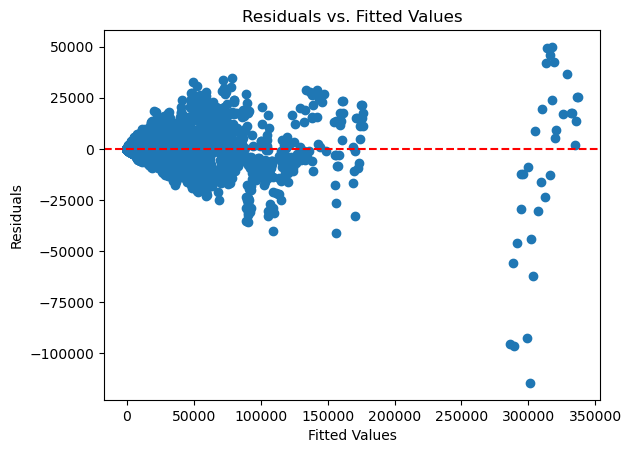

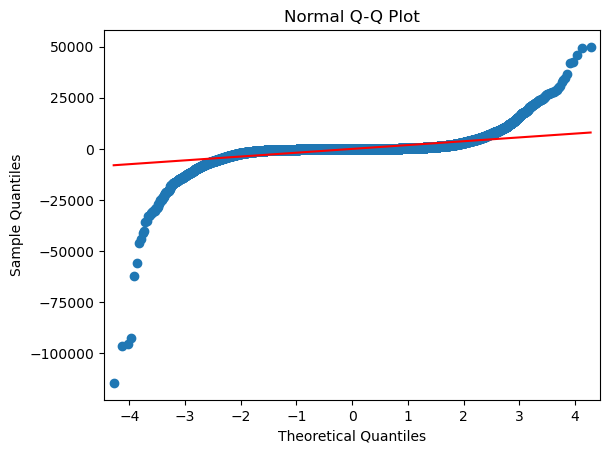

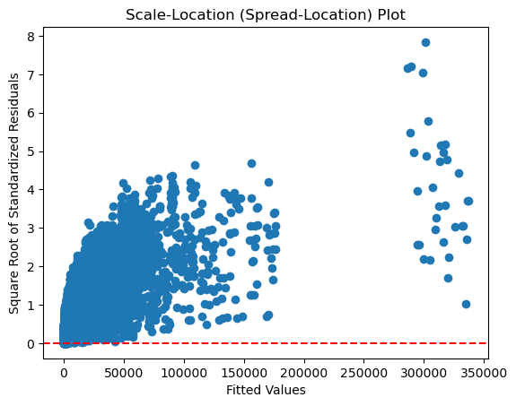

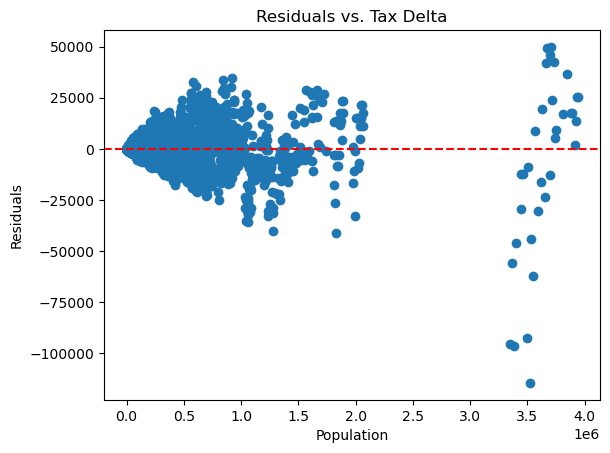

```python
# Validating for linearity assumptions

import statsmodels.api as sm
import matplotlib.pyplot as plt
import scipy.stats as stats
import numpy as np

# Assuming you have already fitted the linear regression model named 'model'

# Get fitted values and residuals
fitted_values = stats_model.fittedvalues
residuals = stats_model.resid

# 1. Residuals vs. Fitted Values Plot
plt.scatter(fitted_values, residuals)
plt.xlabel('Fitted Values')
plt.ylabel('Residuals')
plt.title('Residuals vs. Fitted Values')
plt.axhline(y=0, color='r', linestyle='--')  # Add a horizontal line at y=0
plt.show()

# 2. Normal Q-Q Plot
sm.qqplot(residuals, line='s')
plt.title('Normal Q-Q Plot')
plt.show()

# 3. Scale-Location (Spread-Location) Plot
sqrt_standardized_residuals = np.sqrt(np.abs(stats_model.get_influence().resid_studentized_internal))
plt.scatter(fitted_values, sqrt_standardized_residuals)
plt.xlabel('Fitted Values')
plt.ylabel('Square Root of Standardized Residuals')
plt.title('Scale-Location (Spread-Location) Plot')
plt.axhline(y=0, color='r', linestyle='--')  # Add a horizontal line at y=0
plt.show()

# 4. Residuals vs. Predictor Plot for ''
plt.scatter(df_diab_gender_pivot['Population'], residuals)
plt.xlabel('Population')
plt.ylabel('Residuals')
plt.title('Residuals vs. Tax Delta')
plt.axhline(y=0, color='r', linestyle='--')  # Add a horizontal line at y=0
plt.show()
```

##### Since the above model violates linearity assumptions, applying Box-Cox transoformation

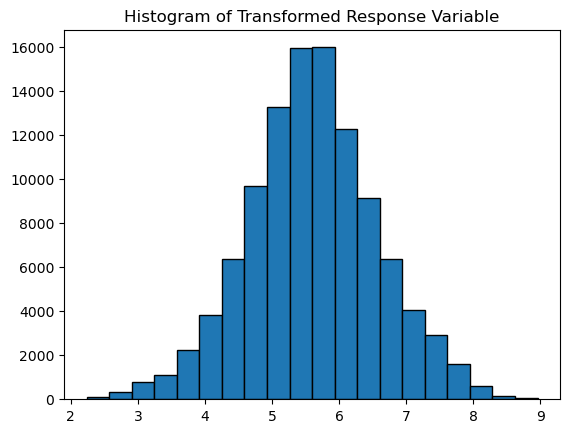

```
Lambda Value: -0.05965469325578518
                            OLS Regression Results
==============================================================================
Dep. Variable:                      y   R-squared:                       0.269
Model:                            OLS   Adj. R-squared:                  0.269
Method:                 Least Squares   F-statistic:                     9814.
Date:                Sat, 25 Nov 2023   Prob (F-statistic):               0.00
Time:                        15:09:09   Log-Likelihood:            -1.3083e+05
No. Observations:              106631   AIC:                         2.617e+05
Df Residuals:                  106626   BIC:                         2.617e+05
Df Model:                           4
Covariance Type:            nonrobust
==================================================================================
                     coef    std err          t      P>|t|      [0.025      0.975]
----------------------------------------------------------------------------------
const              5.1647      0.009    599.220      0.000       5.148       5.182
Grocery Tax       -4.0627      0.122    -33.242      0.000      -4.302      -3.823
Restaurant Tax     6.0637      0.152     39.969      0.000       5.766       6.361
Population      3.997e-06   2.17e-08    184.402      0.000    3.95e-06    4.04e-06
Gender_Male        0.0501      0.005      9.919      0.000       0.040       0.060
==============================================================================
Omnibus:                    41392.963   Durbin-Watson:                   0.056
Prob(Omnibus):                  0.000   Jarque-Bera (JB):           660088.453
Skew:                          -1.443   Prob(JB):                         0.00
Kurtosis:                      14.842   Cond. No.                     7.53e+06
==============================================================================

Notes:
[1] Standard Errors assume that the covariance matrix of the errors is correctly specified.
[2] The condition number is large, 7.53e+06. This might indicate that there are
strong multicollinearity or other numerical problems.
```

```python
# Applying the Box-Cox transformation

# Apply Box-Cox Transformation to Response Variable
y_transformed, lambda_value = stats.boxcox(y + 1)  # Adding 1 to handle zero values

# Visualize the Transformed Response Variable
plt.hist(y_transformed, bins=20, edgecolor='black')
plt.title('Histogram of Transformed Response Variable')
plt.show()

# Check Lambda Value
print(f'Lambda Value: {lambda_value}')

# Fit a new model using the transformed response variable
stats_model_transformed = sm.OLS(y_transformed, X).fit()

# Print the summary of the transformed model
print(stats_model_transformed.summary())
```

##### Conclusion:

- The lambda value is -0.059. Indicating the new model fit is on (((diabetics number^-0.059)-1)/-0.059). We will call this response as transformed y.
- One percent increase in scaled grocery tax, keeping all other constant, decreases the transformed y by 4.06
- One percent increase in scaled restaurant tax, keeping all other constant, increases the transformed by 6.06.
- One unit increase in scaled population, keeping all other constant, increases the transformed y by 3.97*10^-6.
- All p-value are statistically significant
- Adjusted R-square is 0.269 indicating that the model can explain only 26.9% of variation in total number of diabetics patient
- Conditonal large number error still exists. Lets explore scaling to fix it.

```python
import statsmodels.api as sm
from sklearn.preprocessing import StandardScaler
import pandas as pd

df_diab_scaled = df_diab_gender_pivot.reset_index(drop=True)
df_diab_scaled

# Extract the independent variables (features) from your DataFrame
X = pd.get_dummies(df_diab_gender_pivot[['Grocery Tax', 'Restaurant Tax','Population', 'Gender']], columns=['Gender'], drop_first=True)

# Extract the dependent variable from your DataFrame
y = df_diab_scaled['Gender Absolute']

# Initialize the StandardScaler
scaler = StandardScaler()

# Fit and transform the independent variables
X_scaled = scaler.fit_transform(X)

# Create a new DataFrame with the scaled features
X_scaled_df = pd.DataFrame(X_scaled, columns=X.columns)

# Add a constant term to the independent variables
X_scaled_df = sm.add_constant(X_scaled_df)

# Fit the linear regression model
model = sm.OLS(y, X_scaled_df).fit()

# Display the summary
print(model.summary())
```

```
                            OLS Regression Results
==============================================================================
Dep. Variable:        Gender Absolute   R-squared:                       0.966
Model:                            OLS   Adj. R-squared:                  0.966
Method:                 Least Squares   F-statistic:                 7.686e+05
Date:                Sat, 25 Nov 2023   Prob (F-statistic):               0.00
Time:                        15:09:09   Log-Likelihood:            -9.5470e+05
No. Observations:              106631   AIC:                         1.909e+06
Df Residuals:                  106626   BIC:                         1.909e+06
Df Model:                           4
Covariance Type:            nonrobust
==================================================================================
                     coef    std err          t      P>|t|      [0.025      0.975]
----------------------------------------------------------------------------------
const           3290.1045      5.730    574.145      0.000    3278.873    3301.336
Grocery Tax       10.5621      5.820      1.815      0.070      -0.844      21.968
Restaurant Tax    35.6322      5.809      6.134      0.000      24.246      47.018
Population      1.005e+04      5.777   1739.182      0.000       1e+04    1.01e+04
Gender_Male       89.1888      5.731     15.563      0.000      77.957     100.421
==============================================================================
Omnibus:                   128611.608   Durbin-Watson:                   0.331
Prob(Omnibus):                  0.000   Jarque-Bera (JB):        792536352.873
Skew:                          -5.174   Prob(JB):                         0.00
Kurtosis:                     425.224   Cond. No.                         1.20
==============================================================================

Notes:
[1] Standard Errors assume that the covariance matrix of the errors is correctly specified.
```

##### Since the above model violates linearity assumptions, applying Box-Cox transformation to scaled parameters

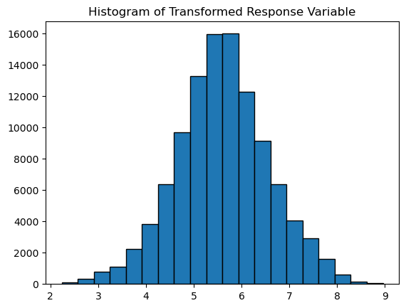

```
Lambda Value: -0.05965469325578518
                            OLS Regression Results
==============================================================================
Dep. Variable:                      y   R-squared:                       0.269
Model:                            OLS   Adj. R-squared:                  0.269
Method:                 Least Squares   F-statistic:                     9814.
Date:                Sat, 25 Nov 2023   Prob (F-statistic):               0.00
Time:                        15:09:10   Log-Likelihood:            -1.3083e+05
No. Observations:              106631   AIC:                         2.617e+05
Df Residuals:                  106626   BIC:                         2.617e+05
Df Model:                           4
Covariance Type:            nonrobust
==================================================================================
                     coef    std err          t      P>|t|      [0.025      0.975]
----------------------------------------------------------------------------------
const              5.6029      0.003   2216.842      0.000       5.598       5.608
Grocery Tax       -0.0853      0.003    -33.242      0.000      -0.090      -0.080
Restaurant Tax     0.1024      0.003     39.969      0.000       0.097       0.107
Population         0.4698      0.003    184.402      0.000       0.465       0.475
Gender_Male        0.0251      0.003      9.919      0.000       0.020       0.030
==============================================================================
Omnibus:                    41392.963   Durbin-Watson:                   0.056
Prob(Omnibus):                  0.000   Jarque-Bera (JB):           660088.472
Skew:                          -1.443   Prob(JB):                         0.00
Kurtosis:                      14.842   Cond. No.                         1.20
==============================================================================

Notes:
[1] Standard Errors assume that the covariance matrix of the errors is correctly specified.
```

```python
# Applying the Box-Cox transformation

# Apply Box-Cox Transformation to Response Variable
y_transformed, lambda_value = stats.boxcox(y + 1)  # Adding 1 to handle zero values

# Visualize the Transformed Response Variable
plt.hist(y_transformed, bins=20, edgecolor='black')
plt.title('Histogram of Transformed Response Variable')
plt.show()

# Check Lambda Value
print(f'Lambda Value: {lambda_value}')

# Fit a new model using the transformed response variable
stats_model_transformed = sm.OLS(y_transformed, X_scaled_df).fit()

# Print the summary of the transformed model
print(stats_model_transformed.summary())
```

##### Conclusion:

The model with response as number of diabetics and predictor variable tax and population:

- The lambda value is -0.059. Indicating the new model fit is on (((diabetics number^-0.059)-1)/-0.059). We will call this response as transformed y.
- One percent increase in scaled grocery tax, keeping all other constant, decreases the transformed y by 0.08
- One percent increase in scaled restaurant tax, keeping all other constant, increases the transformed by 0.1024.
- One percent increase in scaled gender, keeping all other constant, increases the transformed by 0.0251.
- One unit increase in scaled population, keeping all other constant, increases the transformed y by 0.4696.
- All p-value are statistically significant
- Adjusted R-square is 0.269 indicating that the model can explain only 26.9% of variation in total number of diabetics patient
- Conditonal large number error has been fixed

##### b. Total Population and Age - On Absolute Number

```python
import numpy as np
import pandas as pd
import statsmodels.api as sm
from sklearn.model_selection import train_test_split
from sklearn.linear_model import LinearRegression
from sklearn.metrics import mean_squared_error, r2_score

# Assuming 'Grocery Tax' and 'Restaurant Tax' are the features
X = pd.get_dummies(df_diab_age_pivot[['Grocery Tax', 'Restaurant Tax', 'Population','Age']], columns=['Age'], drop_first=True)
y = df_diab_age_pivot['Age Diabetics Absolute']

# Add a constant term to the features matrix (required for statsmodels)
X = sm.add_constant(X)

# Create and fit the linear regression model using statsmodels
stats_model = sm.OLS(y, X).fit()

# Print the summary
print(stats_model.summary())
```

```
                              OLS Regression Results
==================================================================================
Dep. Variable:     Age Diabetics Absolute   R-squared:                       0.607
Model:                                OLS   Adj. R-squared:                  0.607
Method:                     Least Squares   F-statistic:                 4.895e+04
Date:                    Sat, 25 Nov 2023   Prob (F-statistic):               0.00
Time:                            15:09:10   Log-Likelihood:            -1.5646e+06
No. Observations:                  158645   AIC:                         3.129e+06
Df Residuals:                      158639   BIC:                         3.129e+06
Df Model:                               5
Covariance Type:                nonrobust
==================================================================================
                     coef    std err          t      P>|t|      [0.025      0.975]
----------------------------------------------------------------------------------
const          -1691.8083     41.924    -40.354      0.000   -1773.979   -1609.638
Grocery Tax    -6942.6648    563.038    -12.331      0.000   -8046.207   -5839.123
Restaurant Tax  9308.4373    703.593     13.230      0.000    7929.410    1.07e+04
Population         0.0669      0.000    483.757      0.000       0.067       0.067
Age_45-64       2592.3174     28.652     90.475      0.000    2536.160    2648.475
Age_65-beyond   2927.7710     28.766    101.778      0.000    2871.390    2984.152
==============================================================================
Omnibus:                   193271.333   Durbin-Watson:                   2.450
Prob(Omnibus):                  0.000   Jarque-Bera (JB):       1006095713.541
Skew:                           5.330   Prob(JB):                         0.00
Kurtosis:                     392.987   Cond. No.                     5.46e+06
==============================================================================

Notes:
[1] Standard Errors assume that the covariance matrix of the errors is correctly specified.
[2] The condition number is large, 5.46e+06. This might indicate that there are
strong multicollinearity or other numerical problems.
```

##### Conclusion:

- One percent increase in grocery tax, keeping all other constant, decreases the diabetics number by 6942.
- One percent increase in restaurant tax, keeping all other constant, increases the diabetics number by 9308.
- One unit increase in population, keeping all other constant, increases the diabetics number by 0.0669
- Adjusted R-square is 0.607 indicating that the model can explain only 60.7% of variation in total number of diabetics patient
- The conditional number is large and hence we need to check for multicollinearity
- This model has good R-square value but we need to validate the linearity assumptions and if any is violated, apply necessary trasformation

```python
# Checking for multicollinearity
from statsmodels.stats.outliers_influence import variance_inflation_factor

vif_data = pd.DataFrame()
vif_data["Variable"] = X.columns
vif_data["VIF"] = [variance_inflation_factor(X.values, i) for i in range(X.shape[1])]

# Check the VIF values
print(vif_data)
```

```
         Variable        VIF
0           const  12.922238
1     Grocery Tax   1.029523
2  Restaurant Tax   1.026040
3      Population   1.023592
4       Age_45-64   1.346604
5   Age_65-beyond   1.357207
```

##### Inference:

The VIF for predictor variables is small and hence multicollinearity does not exist The VIF with constant variable is high. This can be fixed by scaling if needed.

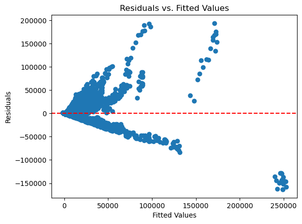

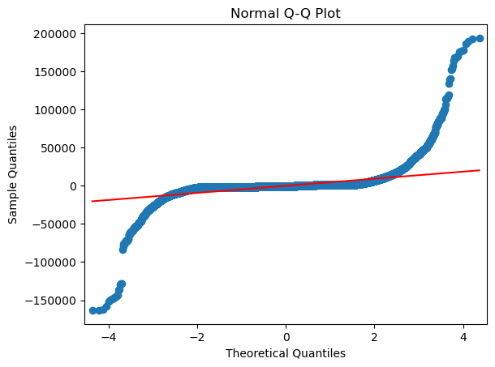

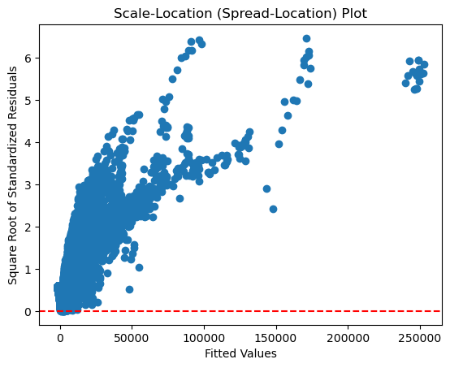

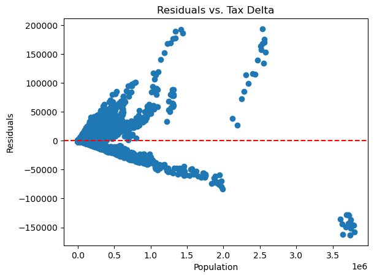

```python
# Validating for linearity assumptions

import statsmodels.api as sm
import matplotlib.pyplot as plt
import scipy.stats as stats
import numpy as np

# Assuming you have already fitted the linear regression model named 'model'

# Get fitted values and residuals
fitted_values = stats_model.fittedvalues
residuals = stats_model.resid

# 1. Residuals vs. Fitted Values Plot
plt.scatter(fitted_values, residuals)
plt.xlabel('Fitted Values')
plt.ylabel('Residuals')
plt.title('Residuals vs. Fitted Values')
plt.axhline(y=0, color='r', linestyle='--')  # Add a horizontal line at y=0
plt.show()

# 2. Normal Q-Q Plot
sm.qqplot(residuals, line='s')
plt.title('Normal Q-Q Plot')
plt.show()

# 3. Scale-Location (Spread-Location) Plot
sqrt_standardized_residuals = np.sqrt(np.abs(stats_model.get_influence().resid_studentized_internal))
plt.scatter(fitted_values, sqrt_standardized_residuals)
plt.xlabel('Fitted Values')
plt.ylabel('Square Root of Standardized Residuals')
plt.title('Scale-Location (Spread-Location) Plot')
plt.axhline(y=0, color='r', linestyle='--')  # Add a horizontal line at y=0
plt.show()

# 4. Residuals vs. Predictor Plot for ''
plt.scatter(df_diab_age_pivot['Population'], residuals)
plt.xlabel('Population')
plt.ylabel('Residuals')
plt.title('Residuals vs. Tax Delta')
plt.axhline(y=0, color='r', linestyle='--')  # Add a horizontal line at y=0
plt.show()
```

##### Since the above model violates linearity assumptions, applying Box-Cox transoformation

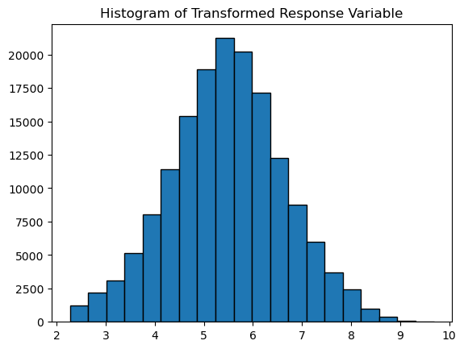

```
Lambda Value: -0.04587186613756453
                            OLS Regression Results
==============================================================================
Dep. Variable:                      y   R-squared:                       0.346
Model:                            OLS   Adj. R-squared:                  0.346
Method:                 Least Squares   F-statistic:                 1.677e+04
Date:                Sat, 25 Nov 2023   Prob (F-statistic):               0.00
Time:                        15:09:16   Log-Likelihood:            -2.1580e+05
No. Observations:              158645   AIC:                         4.316e+05
Df Residuals:                  158639   BIC:                         4.317e+05
Df Model:                           5
Covariance Type:            nonrobust
==================================================================================
                     coef    std err          t      P>|t|      [0.025      0.975]
----------------------------------------------------------------------------------
const              4.4093      0.009    518.073      0.000       4.393       4.426
Grocery Tax       -4.9283      0.114    -43.116      0.000      -5.152      -4.704
Restaurant Tax     6.2689      0.143     43.889      0.000       5.989       6.549
Population      6.075e-06   2.81e-08    216.524      0.000    6.02e-06    6.13e-06
Age_45-64          0.9410      0.006    161.772      0.000       0.930       0.952
Age_65-beyond      0.9887      0.006    169.310      0.000       0.977       1.000
==============================================================================
Omnibus:                    69204.412   Durbin-Watson:                   0.191
Prob(Omnibus):                  0.000   Jarque-Bera (JB):          2257344.123
Skew:                          -1.470   Prob(JB):                         0.00
Kurtosis:                      21.244   Cond. No.                     5.46e+06
==============================================================================

Notes:
[1] Standard Errors assume that the covariance matrix of the errors is correctly specified.
[2] The condition number is large, 5.46e+06. This might indicate that there are
strong multicollinearity or other numerical problems.
```

```python
# Applying the Box-Cox transformation

# Apply Box-Cox Transformation to Response Variable
y_transformed, lambda_value = stats.boxcox(y + 1)  # Adding 1 to handle zero values

# Visualize the Transformed Response Variable
plt.hist(y_transformed, bins=20, edgecolor='black')
plt.title('Histogram of Transformed Response Variable')
plt.show()

# Check Lambda Value
print(f'Lambda Value: {lambda_value}')

# Fit a new model using the transformed response variable
stats_model_transformed = sm.OLS(y_transformed, X).fit()

# Print the summary of the transformed model
print(stats_model_transformed.summary())
```

##### Conclusion:

```python
import statsmodels.api as sm
from sklearn.preprocessing import StandardScaler
import pandas as pd

df_diab_scaled = df_diab_age_pivot.reset_index(drop=True)
df_diab_scaled

# Extract the independent variables (features) from your DataFrame
X = pd.get_dummies(df_diab_scaled[['Grocery Tax', 'Restaurant Tax','Population', 'Age']], columns=['Age'], drop_first=True)
# Extract the dependent variable from your DataFrame
y = df_diab_scaled['Age Diabetics Absolute']

# Initialize the StandardScaler
scaler = StandardScaler()

# Fit and transform the independent variables
X_scaled = scaler.fit_transform(X)

# Create a new DataFrame with the scaled features
X_scaled_df = pd.DataFrame(X_scaled, columns=X.columns)

# Add a constant term to the independent variables
X_scaled_df = sm.add_constant(X_scaled_df)

# Fit the linear regression model
model = sm.OLS(y, X_scaled_df).fit()

# Display the summary
print(model.summary())
```

```
                              OLS Regression Results
==================================================================================
Dep. Variable:     Age Diabetics Absolute   R-squared:                       0.607
Model:                                OLS   Adj. R-squared:                  0.607
Method:                     Least Squares   F-statistic:                 4.895e+04
Date:                    Sat, 25 Nov 2023   Prob (F-statistic):               0.00
Time:                            15:09:17   Log-Likelihood:            -1.5646e+06
No. Observations:                  158645   AIC:                         3.129e+06
Df Residuals:                      158639   BIC:                         3.129e+06
Df Model:                               5
Covariance Type:                nonrobust
==================================================================================
                     coef    std err          t      P>|t|      [0.025      0.975]
----------------------------------------------------------------------------------
const           2211.3428     11.663    189.610      0.000    2188.484    2234.201
Grocery Tax     -145.9156     11.833    -12.331      0.000    -169.109    -122.722
Restaurant Tax   156.2905     11.813     13.230      0.000     133.136     179.445
Population      5708.0212     11.799    483.757      0.000    5684.895    5731.148
Age_45-64       1224.4595     13.534     90.475      0.000    1197.934    1250.985
Age_65-beyond   1382.8377     13.587    101.778      0.000    1356.208    1409.468
==============================================================================
Omnibus:                   193271.333   Durbin-Watson:                   2.450
Prob(Omnibus):                  0.000   Jarque-Bera (JB):       1006095713.550
Skew:                           5.330   Prob(JB):                         0.00
Kurtosis:                     392.987   Cond. No.                         1.76
==============================================================================

Notes:
[1] Standard Errors assume that the covariance matrix of the errors is correctly specified.
```

##### Since the above model violates linearity assumptions, applying Box-Cox transformation to scaled parameters

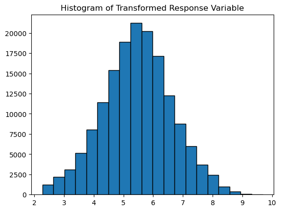

```
Lambda Value: -0.04587186613756453
                            OLS Regression Results
==============================================================================
Dep. Variable:                      y   R-squared:                       0.346
Model:                            OLS   Adj. R-squared:                  0.346
Method:                 Least Squares   F-statistic:                 1.677e+04
Date:                Sat, 25 Nov 2023   Prob (F-statistic):               0.00
Time:                        15:09:18   Log-Likelihood:            -2.1580e+05
No. Observations:              158645   AIC:                         4.316e+05
Df Residuals:                  158639   BIC:                         4.317e+05
Df Model:                           5
Covariance Type:            nonrobust
==================================================================================
                     coef    std err          t      P>|t|      [0.025      0.975]
----------------------------------------------------------------------------------
const              5.4743      0.002   2312.163      0.000       5.470       5.479
Grocery Tax       -0.1036      0.002    -43.116      0.000      -0.108      -0.099
Restaurant Tax     0.1053      0.002     43.889      0.000       0.101       0.110
Population         0.5187      0.002    216.524      0.000       0.514       0.523
Age_45-64          0.4445      0.003    161.772      0.000       0.439       0.450
Age_65-beyond      0.4670      0.003    169.310      0.000       0.462       0.472
==============================================================================
Omnibus:                    69204.413   Durbin-Watson:                   0.191
Prob(Omnibus):                  0.000   Jarque-Bera (JB):          2257344.233
Skew:                          -1.470   Prob(JB):                         0.00
Kurtosis:                      21.244   Cond. No.                         1.76
==============================================================================

Notes:
[1] Standard Errors assume that the covariance matrix of the errors is correctly specified.
```

```python
# Applying the Box-Cox transformation

# Apply Box-Cox Transformation to Response Variable
y_transformed, lambda_value = stats.boxcox(y + 1)  # Adding 1 to handle zero values

# Visualize the Transformed Response Variable
plt.hist(y_transformed, bins=20, edgecolor='black')
plt.title('Histogram of Transformed Response Variable')
plt.show()

# Check Lambda Value
print(f'Lambda Value: {lambda_value}')

# Fit a new model using the transformed response variable
stats_model_transformed = sm.OLS(y_transformed, X_scaled_df).fit()

# Print the summary of the transformed model
print(stats_model_transformed.summary())
```

##### Conclusion:

The model with response as number of diabetics and predictor variable tax and population:

- The lambda value is -0.046. Indicating the new model fit is on (((diabetics number^-0.046)-1)/-0.046). We will call this response as transformed y.
- One percent increase in scaled grocery tax, keeping all other constant, decreases the transformed y by 0.1036
- One percent increase in scaled restaurant tax, keeping all other constant, increases the transformed by 0.1053.
- One unit increase in scaled population, keeping all other constant, increases the transformed y by 0.5187 .
- All p-value are statistically significant
- Adjusted R-square is 0.346 indicating that the model can explain only 34.6% of variation in total number of diabetics patient
- Conditonal large number error has been fixed

### Final Conclusion:

- The best model for explaining Diabetics Number variation with Tax, after accounting for necessary controls and corrections of assumptions, is the model with response, (((diabetics number^-0.046)-1)/-0.046); and scaled predictor grocery tax, restaurant tax, population and age control
- This model explains for 34.6% variability in diabetics number
- We shall continue to research the impact on diabetics percentage and also a study on tax delta.